# Business Problem

Alex Aronson

2022-11-20

**.Using the pedestrian.csv data set, train a GLM using a Poisson distribution with log link function to identify and interpret factors that relate to higher or lower counts of pedestrians.**

```r
library(dplyr)
```

```r
library(ggplot2)
ped<- read.csv("pedestrian.csv")
head(ped)
```

```
##   pedestrians             weather temperature precipitation hour   weekday
## 1        3172           clear-day          44        0.0000   14 Wednesday
## 2          14 partly-cloudy-night          41        0.0000   21    Sunday
## 3          10 partly-cloudy-night          36        0.0000   21  Thursday
## 4         521   partly-cloudy-day          76        0.0087    9   Tuesday
## 5         126         clear-night          35        0.0000    6    Monday
## 6        2628   partly-cloudy-day          73        0.0000   19  Saturday
##   temp_forecast
## 1      37.11765
## 2      41.17647
## 3      40.17647
## 4      75.76471
## 5      50.05882
## 6      70.76471
```

```r
str(ped)
```

```
## 'data.frame':    11373 obs. of  7 variables:
##  $ pedestrians  : int  3172 14 10 521 126 2628 1602 23 37 2709 ...
##  $ weather      : chr  "clear-day" "partly-cloudy-night" "partly-cloudy-night" "partly-cloudy-day" ...
##  $ temperature  : int  44 41 36 76 35 73 48 32 57 41 ...
##  $ precipitation: num  0 0 0 0.0087 0 0 0 0.0037 0 0 ...
##  $ hour         : int  14 21 21 9 6 19 15 21 21 15 ...
##  $ weekday      : chr  "Wednesday" "Sunday" "Thursday" "Tuesday" ...
##  $ temp_forecast: num  37.1 41.2 40.2 75.8 50.1 ...
```

```r
ped$weather<- as.factor(ped$weather)
ped$weekday<- as.factor(ped$weekday)
head(ped)
```

```
##   pedestrians             weather temperature precipitation hour   weekday
## 1        3172           clear-day          44        0.0000   14 Wednesday
## 2          14 partly-cloudy-night          41        0.0000   21    Sunday
## 3          10 partly-cloudy-night          36        0.0000   21  Thursday
## 4         521   partly-cloudy-day          76        0.0087    9   Tuesday
## 5         126         clear-night          35        0.0000    6    Monday
## 6        2628   partly-cloudy-day          73        0.0000   19  Saturday
##   temp_forecast
## 1      37.11765
## 2      41.17647
## 3      40.17647
## 4      75.76471
## 5      50.05882
## 6      70.76471
```

```r
str(ped)
```

```
## 'data.frame':    11373 obs. of  7 variables:
##  $ pedestrians  : int  3172 14 10 521 126 2628 1602 23 37 2709 ...
##  $ weather      : Factor w/ 10 levels "clear-day","clear-night",..: 1 6 6 5 2 5 5 3 3 1 ...
##  $ temperature  : int  44 41 36 76 35 73 48 32 57 41 ...
##  $ precipitation: num  0 0 0 0.0087 0 0 0 0.0037 0 0 ...
##  $ hour         : int  14 21 21 9 6 19 15 21 21 15 ...
##  $ weekday      : Factor w/ 7 levels "Friday","Monday",..: 7 4 5 6 2 3 6 2 2 4 ...
##  $ temp_forecast: num  37.1 41.2 40.2 75.8 50.1 ...
```

**Building Model/Exploring Data.**

```r
ped.aov<- aov(pedestrians~.,data=ped)
summary(ped.aov)
```

```
##                  Df    Sum Sq   Mean Sq F value   Pr(>F)
## weather           9 3.132e+09 3.480e+08 1117.23  < 2e-16 ***
## temperature       1 6.762e+08 6.762e+08 2170.80  < 2e-16 ***
## precipitation     1 7.968e+06 7.968e+06   25.58 4.32e-07 ***
## hour              1 3.329e+08 3.329e+08 1068.75  < 2e-16 ***
## weekday           6 2.546e+08 4.244e+07  136.23  < 2e-16 ***
## temp_forecast     1 1.047e+09 1.047e+09 3362.54  < 2e-16 ***
## Residuals     11353 3.537e+09 3.115e+05
## ---
## Signif. codes:  0 '***' 0.001 '**' 0.01 '*' 0.05 '.' 0.1 ' ' 1
```

- I chose to take look at an ANOVA summary using all factors in order to see which ones were potentially insignificant on a $\alpha=0.05$ level, as we can see from the summary it looks like every factor in the data set has a significant effect on the outcome of pedestrian traffic.

```r
# checking continuous variables

cont<- select_if(ped, is.numeric)
summary(cont)
```

```
##   pedestrians      temperature    precipitation           hour
##  Min.   :   1.0   Min.   : 2.00   Min.   :0.000000   Min.   : 6
##  1st Qu.: 170.0   1st Qu.:40.00   1st Qu.:0.000000   1st Qu.:10
##  Median : 698.0   Median :54.00   Median :0.000000   Median :14
##  Mean   : 962.5   Mean   :54.47   Mean   :0.004894   Mean   :14
##  3rd Qu.:1639.0   3rd Qu.:70.00   3rd Qu.:0.000000   3rd Qu.:18
##  Max.   :4331.0   Max.   :97.00   Max.   :0.554300   Max.   :22
##  temp_forecast
##  Min.   : 9.235
##  1st Qu.:40.176
##  Median :53.647
##  Mean   :54.470
##  3rd Qu.:70.765
##  Max.   :90.706
```

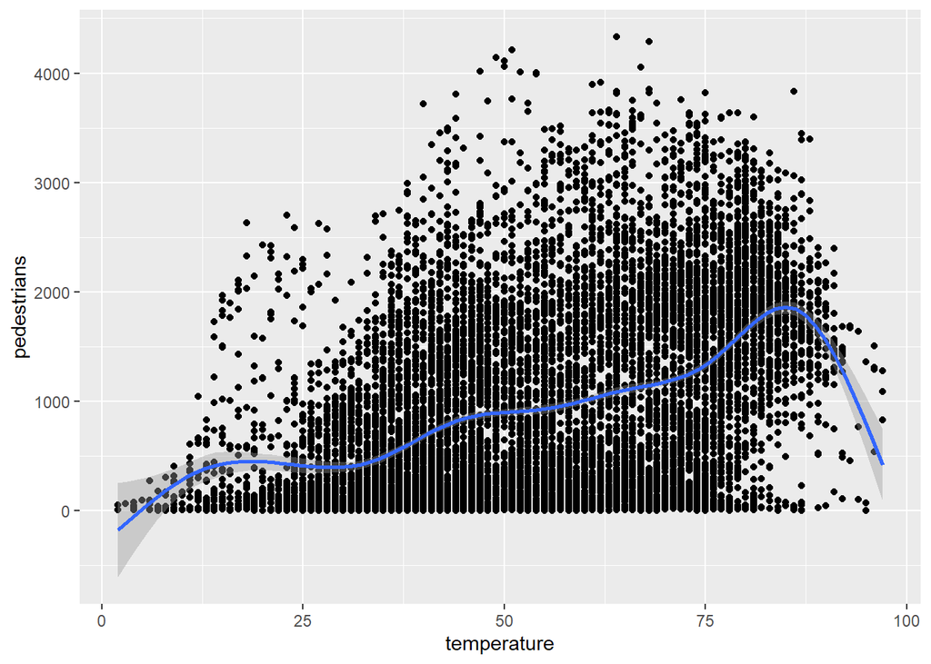

```r
# Visualizing Variables vs Pedestrians data
library(ggplot2)

ggplot(ped, aes(temperature, pedestrians)) +geom_point() +  geom_smooth()
```

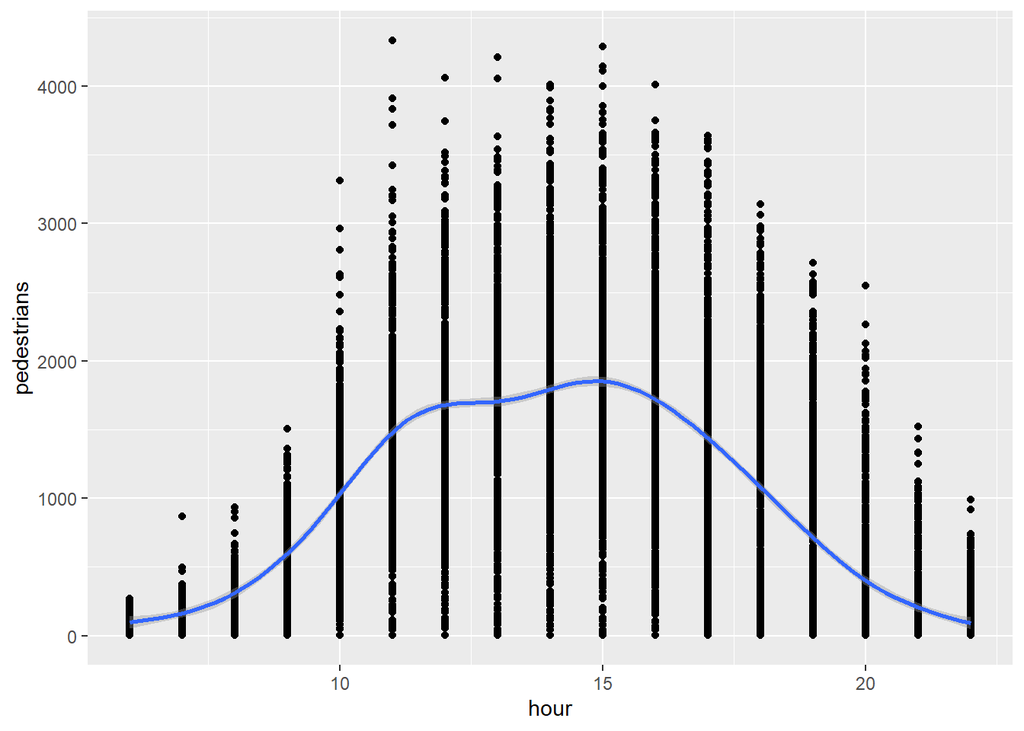

```r
ggplot(ped, aes(hour, pedestrians)) +geom_point() +  geom_smooth()
```

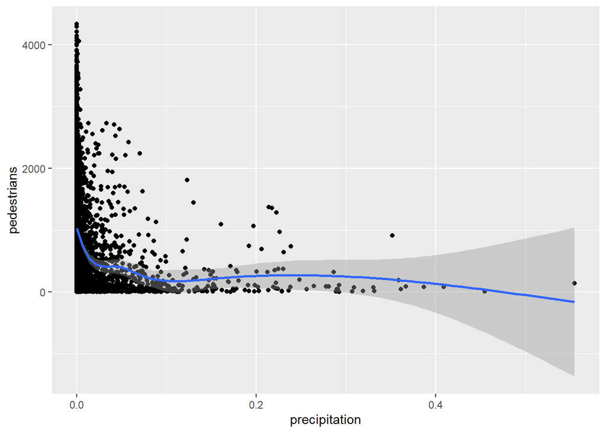

```r
ggplot(ped, aes(precipitation, pedestrians)) +geom_point() +  geom_smooth()
```

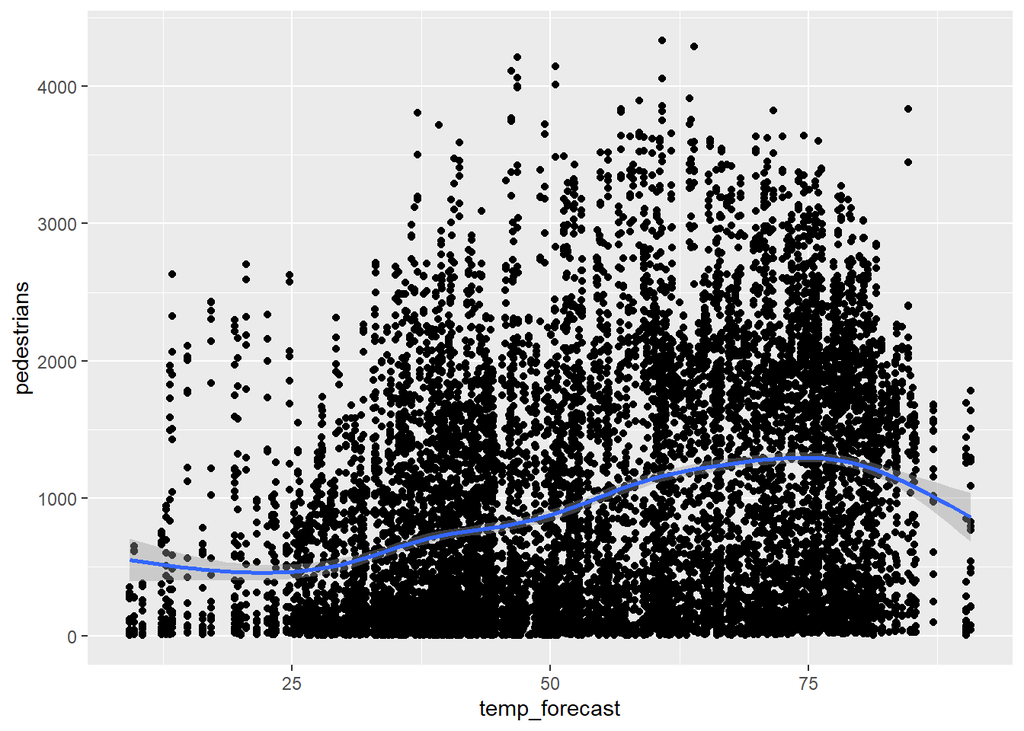

```r
ggplot(ped, aes(temp_forecast, pedestrians)) +geom_point() +  geom_smooth()
```

```r
# splitting data

training<- ped %>% dplyr::sample_frac(0.8)
dim(training)
```

```
## [1] 9098    7
```

```r
testing<- dplyr::anti_join(ped, training, by='pedestrians')
dim(testing)
```

```
## [1] 210   7
```

```r
# modeling data

mod<- glm(pedestrians ~ ., data= training, family = poisson(link="log"))
summary(mod)
```

```
##
## Call:
## glm(formula = pedestrians ~ ., family = poisson(link = "log"),
##     data = training)
##
## Deviance Residuals:
##     Min       1Q   Median       3Q      Max
## -78.462  -14.303   -3.063    8.877   86.702
##
## Coefficients:
##                              Estimate Std. Error z value Pr(>|z|)
## (Intercept)                 6.4748449  0.0019724 3282.64   <2e-16 ***
## weatherclear-night         -1.5157532  0.0021899 -692.17   <2e-16 ***
## weathercloudy              -0.3457169  0.0011807 -292.81   <2e-16 ***
## weatherfog                 -0.9488223  0.0082664 -114.78   <2e-16 ***
## weatherpartly-cloudy-day   -0.0269285  0.0007683  -35.05   <2e-16 ***
## weatherpartly-cloudy-night -1.7241135  0.0025716 -670.44   <2e-16 ***
## weatherrain                -0.8808480  0.0032121 -274.23   <2e-16 ***
## weathersleet               -1.2850880  0.0251163  -51.16   <2e-16 ***
## weathersnow                -1.1637217  0.0085442 -136.20   <2e-16 ***
## weatherwind                -0.2459221  0.0207398  -11.86   <2e-16 ***
## temperature                 0.0947943  0.0001038  913.29   <2e-16 ***
## precipitation              -5.7412139  0.0458788 -125.14   <2e-16 ***
## hour                        0.0080732  0.0001096   73.69   <2e-16 ***
## weekdayMonday              -0.0602895  0.0012814  -47.05   <2e-16 ***
## weekdaySaturday             0.2578308  0.0011851  217.56   <2e-16 ***
## weekdaySunday               0.1264156  0.0012409  101.88   <2e-16 ***
## weekdayThursday            -0.1101900  0.0013194  -83.51   <2e-16 ***
## weekdayTuesday             -0.1422688  0.0013110 -108.52   <2e-16 ***
## weekdayWednesday           -0.1667633  0.0013265 -125.72   <2e-16 ***
## temp_forecast              -0.0863544  0.0001057 -817.04   <2e-16 ***
## ---
## Signif. codes:  0 '***' 0.001 '**' 0.01 '*' 0.05 '.' 0.1 ' ' 1
##
## (Dispersion parameter for poisson family taken to be 1)
##
##     Null deviance: 7806215  on 9097  degrees of freedom
## Residual deviance: 2806768  on 9078  degrees of freedom
## AIC: 2878796
##
## Number of Fisher Scoring iterations: 6
```

```r
coef(mod)
```

```
##                (Intercept)         weatherclear-night
##                6.474844921               -1.515753225
##              weathercloudy                 weatherfog
##               -0.345716900               -0.948822259
##   weatherpartly-cloudy-day weatherpartly-cloudy-night
##               -0.026928474               -1.724113507
##                weatherrain               weathersleet
##               -0.880848001               -1.285088040
##                weathersnow                weatherwind
##               -1.163721695               -0.245922101
##                temperature              precipitation
##                0.094794281               -5.741213862
##                       hour              weekdayMonday
##                0.008073177               -0.060289468
##            weekdaySaturday              weekdaySunday
##                0.257830788                0.126415620
##            weekdayThursday             weekdayTuesday
##               -0.110190040               -0.142268826
##           weekdayWednesday              temp_forecast
##               -0.166763330               -0.086354374
```

```r
# running predictions of testing data.

testing$predictions<- predict(mod, newdata=testing, type="response",se.fit=FALSE)
head(testing)
```

```
##   pedestrians           weather temperature precipitation hour  weekday
## 1        1591 partly-cloudy-day          88             0   12   Monday
## 2        3032 partly-cloudy-day          81             0   15 Saturday
## 3        3616 partly-cloudy-day          64             0   14 Saturday
## 4        2575         clear-day          66             0   12   Monday
## 5        2964         clear-day          57             0   17 Saturday
## 6        2535 partly-cloudy-day          75             0   14   Friday
##   temp_forecast predictions
## 1      84.88235    1801.616
## 2      73.35294    3536.293
## 3      60.64706    2097.428
## 4      60.70588    1854.996
## 5      53.00000    2200.438
## 6      71.23529    1842.784
```

```r
mod2<- glm(pedestrians~.,family= poisson(link = "log"), data = ped )
summary(ped)
```

```
##   pedestrians                    weather      temperature    precipitation
##  Min.   :   1.0   partly-cloudy-day  :3169   Min.   : 2.00   Min.   :0.000000
##  1st Qu.: 170.0   clear-day          :3127   1st Qu.:40.00   1st Qu.:0.000000
##  Median : 698.0   cloudy             :1601   Median :54.00   Median :0.000000
##  Mean   : 962.5   clear-night        :1565   Mean   :54.47   Mean   :0.004894
##  3rd Qu.:1639.0   partly-cloudy-night:1081   3rd Qu.:70.00   3rd Qu.:0.000000
##  Max.   :4331.0   rain               : 679   Max.   :97.00   Max.   :0.554300
##                   (Other)            : 151
##       hour         weekday     temp_forecast
##  Min.   : 6   Friday   :1615   Min.   : 9.235
##  1st Qu.:10   Monday   :1632   1st Qu.:40.176
##  Median :14   Saturday :1615   Median :53.647
##  Mean   :14   Sunday   :1632   Mean   :54.470
##  3rd Qu.:18   Thursday :1615   3rd Qu.:70.765
##  Max.   :22   Tuesday  :1649   Max.   :90.706
##               Wednesday:1615
```

```r
ped$predicted<- predict(mod2, data= ped, type="response")
head(ped)
```

```
##   pedestrians             weather temperature precipitation hour   weekday
## 1        3172           clear-day          44        0.0000   14 Wednesday
## 2          14 partly-cloudy-night          41        0.0000   21    Sunday
## 3          10 partly-cloudy-night          36        0.0000   21  Thursday
## 4         521   partly-cloudy-day          76        0.0087    9   Tuesday
## 5         126         clear-night          35        0.0000    6    Monday
## 6        2628   partly-cloudy-day          73        0.0000   19  Saturday
##   temp_forecast  predicted
## 1      37.11765 1612.65110
## 2      41.17647  209.06029
## 3      40.17647  113.67111
## 4      75.76471 1087.96017
## 5      50.05882   50.86552
## 6      70.76471 2165.79545
```

```r
ped %>%
  group_by(hour) %>%
  summarise(sum(pedestrians))
```

```
## # A tibble: 17 × 2
##     hour `sum(pedestrians)`
##    <int>              <int>
##  1     6              59092
##  2     7             124159
##  3     8             207902
##  4     9             371424
##  5    10             708123
##  6    11            1000090
##  7    12            1103218
##  8    13            1153841
##  9    14            1194052
## 10    15            1230625
## 11    16            1173634
## 12    17             951737
## 13    18             713842
## 14    19             490098
## 15    20             279144
## 16    21             116072
## 17    22              69802
```

```r
ped %>%
  group_by(weekday) %>%
  summarise(sum(pedestrians))
```

```
## # A tibble: 7 × 2
##   weekday   `sum(pedestrians)`
##   <fct>                  <int>
## 1 Friday               1574378
## 2 Monday               1472177
## 3 Saturday             2131909
## 4 Sunday               1720125
## 5 Thursday             1360784
## 6 Tuesday              1386343
## 7 Wednesday            1301139
```

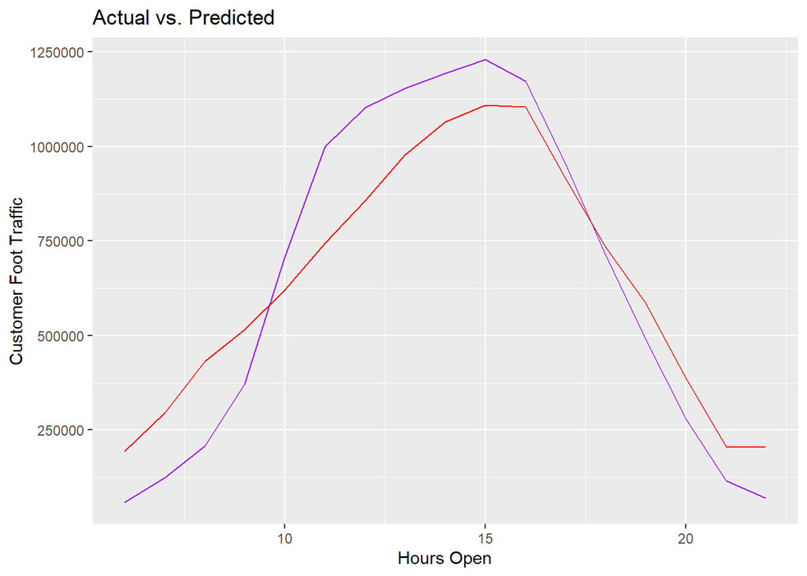

```r
ped %>%
  group_by(hour) %>%
  summarise(Actual = sum(pedestrians),
            Predicted = sum(predicted)) %>%
  ggplot(aes(x = hour)) +
        geom_line(aes(y = `Actual`), color = "purple", group = 1)+
        geom_line(aes(y = `Predicted`), color = "red", group = 1) + labs(title= "Actual vs. Predicted", x= "Hours Open", y= "Customer Foot Traffic")
```